# CourseMatch Analytics - Fall 2018

Data Processing for Google Sheet

2018-07-31

```r
#setwd("<insert path>")

# knitr options
knitr::opts_chunk$set(echo = TRUE, message = FALSE, warning = FALSE, fig.align = 'center',
                      fig.width = 9, fig.height = 8, cache = FALSE)

# Forces any incline R to only have 2 digits and a comma for the thounsands place
knitr::knit_hooks$set(inline = function(x) {if(!is.numeric(x)){ x }else{ prettyNum(round(x,2), big.mark=",") } })

# Don't show scientific notation and only 3 digits
options(scipen = 999, digits = 3)

# Load packages
pacman::p_load(tidyverse, readxl, stringr, lubridate, googlesheets, rvest, forcats,
               grid, gridExtra, htmlTable, highcharter)

# Token to connect to Googlespreadsheets
#token <- gs_auth(cache = FALSE)
#saveRDS(token, file = "googlesheets_token.rds")
suppressMessages(gs_auth(token = "googlesheets_token.rds", verbose = FALSE))

# Create corresponding folders in working directory
data_path <- "data/"; viz_path <- "viz/"

#Set ggplot theme
ggplot2::theme_set(theme_minimal() +
                     theme(legend.position="top", plot.caption = element_text(size = 8),
                           panel.grid.minor.x = element_blank(),
                           strip.background = element_rect(fill = "grey85", colour = "grey85"),
                           legend.margin=margin(t = -0.3, r = 0, b = -0.4, l=0, unit="cm")))

wharton_col <- c("#004785", "#A90533", "#A262460", "#282F85", "#026CB5", "#06AAFC",
                 "#532A85","#96227D", "#A8204E","#C5093B","#2D2C41","#D7BC6A",
                 "#B2B6A7","EEEDEA")
names(wharton_col) <- c("wharton_blue", 'wharton_red','midnight_blue','atlantic_blue','pacific_blue','bay_blue',
                        'evening_red','sunset_red','brick_red','heritage_red','night_street','morning_yellow',
                        'college_grey','marine_grey')

hcoptslang <- getOption("highcharter.lang")
hcoptslang$thousandsSep <- ","
hcoptslang$numericSymbols <- c("k", "M", "B", "T", "P", "E")
options(highcharter.lang = hcoptslang)
```

## 0.1 Summary

1. This notebook documents how we built the [Google Sheet](https://docs.google.com/spreadsheets/d/1TcQDKsTKqq858u0LV7ETY9cunvEIMRpFV3-7gm4fe9Y/edit?usp=sharing) with course and instructor evaluations and clearing prices
2. There some basic exploratory plots at the end

# 1 Data Acquisition

## 1.1 CourseMatch Sections

To get all sections listed in CourseMatch, we extract the table from the html. First, save the home CourseMatch interface page as a .html file in the data folder. Some courses are cross-listed and we create a column to include the other sections a course can be listed as.

```r
# List of sections available for selection within CourseMatch
coursematch_sections <-
  read_html(paste0(data_path, "Course Match.html")) %>%
  html_node(xpath = '//*[@id="preferences-table"]') %>%
  html_table(header = TRUE, trim = TRUE) %>%
  as_tibble() %>%
  select(1) %>%
  rename_at(vars(contains("Dept")), funs(paste0("Course_Multiple"))) %>%
  mutate(Section = str_extract_all(Course_Multiple, "[A-Z]{4}[0-9]{6}")) %>%
  unnest() %>%
  mutate(cross_listed_as = str_replace(Course_Multiple, Section, "")) %>%
  mutate(cross_listed_as = if_else(cross_listed_as == "", NA_character_, cross_listed_as)) %>%
  distinct(Section, cross_listed_as) %>%
  rowwise() %>%
  mutate(cross_listed_as = if_else(cross_listed_as == "", NA_character_,
                                   paste0(str_extract_all(cross_listed_as,
                                                          "[A-Z]{4}[0-9]{6}", simplify = TRUE), collapse = ","))) %>%
  ungroup()
```

## 1.2 Course Information

```r
fall_2018_courses <-
  readxl::read_excel(paste0(data_path, "export_courses.xls"))
```

## 1.3 Course Evaluations

Course evaluation comes from a [Spike export](https://spike.wharton.upenn.edu/courses/?method=export_evaluations). You need to open the Excel file and resave before it will load into R (see documented issue caused by the way this file was built by Spike).

```r
course_eval <-
  readxl::read_excel(paste0(data_path, "CourseEvaluationData.xls"), skip = 1) %>%
  filter(n() != row_number())
```

## 1.4 Clearing Prices

Clearing price data comes the **public** [MBA Inside website](https://mba-inside.wharton.upenn.edu/course-match/). We save the files corresponding to the last 4 semesters, from Fall 2016 to Spring 2018

```r
# Function to load each xlsx file of clearing prices
# Need to have a switch because the Fall 2013 file
# contains an extra row at the top
fn_load_clearing_price_xlsx <- function(file_name) {
  if (str_detect(file_name, "13")) {
    readxl::read_excel(file_name, skip = 1)
  } else {
    readxl::read_excel(file_name, skip = 0)
  }
}

# Function to rename the columns that
# look like 'section' and 'price' to Section
# and Price so that they can be binded
fn_rename_at <- function(df, string) {
  df %>%
    rename_at(vars(matches(string)), funs(paste0(string)))
}

# Load and coalesce each of the clearing price
# Excel files
clearing_prices <-
  list.files(paste0(data_path, "clearing_prices/"), full.names = TRUE) %>%
  map(fn_load_clearing_price_xlsx) %>%
  map(select, matches("Section|Price")) %>%
  map(fn_rename_at, string = "Section") %>%
  map(fn_rename_at, string = "Price") %>%
  bind_rows() %>%
  mutate(Course = str_sub(Section, 1, 7)) %>%
  select(Course, Section, Price)
```

# 2 Data Cleaning

After acquiring data from the four data sources we need to do some combining and cleaning.

```r
fall_2018 <-
  fall_2018_courses %>%
  select(-Max, -Status) %>%
  distinct() %>%
  mutate(Section = strsplit(as.character(Section), " / ")) %>%
  unnest(Section) %>%
  select(Section, everything()) %>%
  inner_join(coursematch_sections, by = "Section") %>%
  mutate(title_length = length(Title)) %>%
  arrange(Section, desc(title_length)) %>%
  group_by(Section) %>%
  filter(row_number() == 1) %>%
  ungroup() %>%
  mutate(
    Course = str_sub(Section, 1, 7)
    , Section = str_sub(Section, 8, 10)
    , CU = as.numeric(CU)
  ) %>%
  select(Course, Section, Title, Instructor, CU, Dates, `Day(s)`, cross_listed_as) %>%
  separate(Dates, c("start_date", "end_date"), sep = "-") %>%
  mutate(
    start_date = lubridate::mdy(start_date)
    , Days = stringr::str_extract(`Day(s)`, "^([\\w]+)")
    , Quarter = if_else(CU == 1, "Full", if_else(lubridate::month(start_date) == 8, "Q1", "Q2"))
    , start_time = stringr::str_extract(`Day(s)`, "(?:\\S+){2}(\\S+)")
    , end_time = str_trim(stringr::str_extract(`Day(s)`, "\\s(\\S+)$"))
    , Title = str_to_title(Title)
  ) %>%
  select(-start_date, -end_date, -`Day(s)`)
```

```r
tbl_questions <- tribble(
  ~question_type, ~question, ~question_abbr
  , 'Course', 'Overall Quality of Course (0=worst 4=best)', 'Course Quality'
  , 'Course', 'Value of Assigned Readings (0=worst 4=best)', 'Value of Assigned Readings'
  , 'Course', 'Learned from this Course in terms of Knowledge / Concepts / Skills / Thinking Ability (0=worst 4=best)', 'Amount Learned'
  , 'Course', 'Rate the Difficulty of this Course (0=easiest 4=hardest)', 'Difficulty'
  , 'Course', 'Rate the Amount of Work Required for this Course (0=easiest 4=hardest)', 'Amount of Work Required'
  , 'Course', 'Would you Recommend this Course to a Major? (4=most strongly)', 'Recommend to Major?'
  , 'Course', 'Would you Recommend this Course to a Non-Major? (4=most strongly)', 'Recommend to Non-Major'
  , 'Instructor', 'Overall Quality of Instructor (0=worst 4=best)', 'Instructor Quality'
  , 'Instructor', 'Instructor Ability to Communicate Subject Matter (0=worst 4=best)', 'Ability to Communicate Subject Matter'
  , 'Instructor',  'Instructor Ability to Stimulate Student Interest (0=worst 4=best)', 'Ability to Stimulate Interest'
  , 'Instructor', 'Instructor Accessibility / Willingness to Discuss Course Content / Problems (0=worst 4=best)', 'Instructor Accessibility'
) %>%
  mutate(
    question_type = fct_inorder(question_type)
    , question_abbr = fct_inorder(question_abbr)
  )
```

```r
tbl_course_lookup <-
  tribble(
    ~evaluated_course, ~coursematch_course,
    'ACCT208',  'ACCT718',
    'BEPP201',  'BEPP770',
    'BEPP305',  'BEPP805',
    'STAT451',  'BEPP851',
    'STAT453',  'BEPP853',
    #'REAL721', 'FNCE721',
    #'OIDD693', 'LGST693',
    #'LGST809', 'MGMT815',
    'OIDD415',  'OIDD515',
    'STAT470',  'STAT770',
    'STAT451',  'STAT851',
    'STAT453',  'STAT853',
    NA_character_, 'MGMT833',
    NA_character_, 'LGST641',
    'OIDD691', 'MGMT691',
    'LGST806', 'MGMT691'
  )
```

```r
cross_listed_course <-
  tribble(
    ~coursematch, ~evaluated_as
    , "FNCE721", "REAL721" # Real Estate Investments
    , "MGMT815", "LGST809" # Sports Business Mgmt
    , "MGMT690", "OIDD690" # Managerial Decisn Making
    , "LGST693", "OIDD693" # Influence
    , "LGST804", "REAL804" # Real Estate Law
    , "OIDD691", "MGMT691" # Negotiations
    , "LGST806", "MGMT691" # Negotiations
  )
```

```r
course_eval_cleaned <-
  course_eval %>%
  gather(question, value, -Term, -Section, -Title, -Instructor) %>%
  left_join(tbl_questions, by = 'question') %>%
  select(-question) %>%
  mutate(
    Year = str_sub(Term, 1,4)
    , Course = str_sub(Section, 1, 7)
  ) %>%
  left_join(tbl_course_lookup, by = c('Course' = 'evaluated_course')) %>%
  mutate(Course = if_else(is.na(coursematch_course), Course, coursematch_course)) %>%
  mutate(
    Course_Num = str_sub(Course, 5, 7)
    , Dept = str_sub(Course, 1, 4)
  ) %>%
  select(Year, Dept, Course_Num, Course, Section, Title, Instructor, question_type, question_abbr, value) %>%
  # OIDD515 (Product Design) is the only CourseMatch class with a course number less than 600
  filter(Course == "OIDD515" | (Course_Num >= 600 & Course_Num < 900))
```

| 10 sample rows from the tidied course evaluation data Year | 10 sample rows from the tidied course evaluation data Dept | 10 sample rows from the tidied course evaluation data Course Number | 10 sample rows from the tidied course evaluation data Course | 10 sample rows from the tidied course evaluation data Section | 10 sample rows from the tidied course evaluation data Title | 10 sample rows from the tidied course evaluation data Instructor | 10 sample rows from the tidied course evaluation data Question Type | 10 sample rows from the tidied course evaluation data Question | 10 sample rows from the tidied course evaluation data Value |
| --- | --- | --- | --- | --- | --- | --- | --- | --- | --- |
| 2018 | MGMT | 701 | MGMT701 | MGMT701002 | STRAT & COMPET ADVANTAGE | Menon, Anoop | Course | Value of Assigned Readings | 2.98 |
| 2018 | OIDD | 612 | OIDD612 | OIDD612002 | BUSINESS ANALYTICS | Tsoukalas, Gerry | Course | Amount of Work Required | 2.57 |
| 2017 | FNCE | 613 | FNCE613 | FNCE613006 | MACROECN & GLOBAL ECONOM | Landry, Anthony | Instructor | Ability to Communicate Subject Matter | 2.94 |
| 2017 | LGST | 612 | LGST612 | LGST612001 | RESPONSIBILITY IN BUS. | Werbach, Kevin | Course | Recommend to Non-Major | 2.67 |
| 2017 | MKTG | 770 | MKTG770 | MKTG770402 | Digital Marketing, Social Media and E-Commerce | Berman, Ron | Instructor | Instructor Accessibility | 3.3 |
| 2018 | MGMT | 613 | MGMT613 | MGMT613751 | MANAG ESTAB ENTERPRISE | Siggelkow, Nicolaj | Course | Amount Learned | 3.61 |
| 2017 | OIDD | 690 | OIDD690 | OIDD690402 | MANAG DECSN MAKING | Milkman, Katherine | Course | Amount Learned | 3.4 |
| 2017 | MKTG | 893 | MKTG893 | MKTG893402 | MKTG in Emerging Economies: Understanding & MKTG to the Chinese Consumer | Zhang, John | Instructor | Ability to Stimulate Interest | 3.27 |
| 2018 | FNCE | 728 | FNCE728 | FNCE728001 | CORPORATE VALUATION | Glode, Vincent | Course | Amount of Work Required | 3.48 |
| 2018 | ACCT | 747 | ACCT747 | ACCT747001 | FIN STATEMENT & DIS ANA | Bushee, Brian | Course | Recommend to Non-Major | 2.49 |

# 3 Summaries for Google Sheet

We present that data at two levels of detail:

1. **Course View**: Aggregate the reviews for all sections a course was taught
2. **Instructor View**: Aggregate the reviews for all sections an instructor has taught

## 3.1 Course View

```r
course_metrics <-
  fall_2018 %>%
  left_join(cross_listed_course, by = c('Course' = 'coursematch')) %>%
  mutate(evaluated_as = if_else(is.na(evaluated_as), Course, evaluated_as)) %>%
  left_join(
    course_eval_cleaned %>%
      filter(question_type == "Course") %>%
      group_by(Course, question_abbr) %>%
      summarise(
        value = mean(value)
        , sections_evaluated = n()
      ) %>%
      spread(question_abbr, value)
    , by = c('evaluated_as' = 'Course')
  ) %>%
  left_join(
    clearing_prices %>%
      filter(str_sub(Course, 1, 4) != "WHCP") %>%
      mutate(Course = str_replace(Course, "OPIM", "OIDD")) %>%
      left_join(cross_listed_course, by = c('Course' = 'coursematch')) %>%
      mutate(evaluated_as = if_else(is.na(evaluated_as), Course, evaluated_as)) %>%
      group_by(evaluated_as) %>%
      summarise(clearing_price = mean(Price)) %>%
      ungroup() %>%
      mutate(percentile = percent_rank(clearing_price))
    , by = c("evaluated_as")
  ) %>%
  select(-evaluated_as) %>%
  select(-one_of('cross_listed_as'), one_of('cross_listed_as'))
```

```r
course_benchmark <-
  course_eval_cleaned %>%
  filter(question_type == "Course") %>%
  group_by(question_abbr) %>%
  summarise(
    value = mean(value)
    , sections_evaluated = n()
  ) %>%
  spread(question_abbr, value) %>%
  bind_cols(
    clearing_prices %>%
      filter(str_sub(Course, 1, 4) != "WHCP") %>%
      summarise(clearing_price = mean(Price))
  )
```

## 3.2 Instructor View

```r
instructor_metrics <-
  fall_2018 %>%
  mutate(instructors = strsplit(Instructor, "/")) %>%
  unnest(instructors) %>%
  mutate(instructors = str_trim(instructors)) %>%
  filter(!(is.na(instructors) | instructors == "")) %>%
  distinct(instructors) %>%
  left_join(
    course_eval_cleaned %>%
      filter(question_type == "Instructor") %>%
      group_by(Instructor, question_abbr) %>%
      summarise(
        value = mean(value)
        , sections_evaluated = n()
      ) %>%
      spread(question_abbr, value)
    , by = c('instructors' = 'Instructor')
  ) %>%
  arrange(instructors)
```

```r
instructor_benchmark <-
  course_eval_cleaned %>%
  filter(question_type == "Instructor") %>%
  group_by(question_abbr) %>%
  summarise(
    value = mean(value)
    , sections_evaluated = n()
  ) %>%
  spread(question_abbr, value)
```

## 3.3 Export to Google Sheet

We then use the [googlesheets](https://cran.r-project.org/web/packages/googlesheets/) package to add them to the [Google Sheet](https://docs.google.com/spreadsheets/d/1TcQDKsTKqq858u0LV7ETY9cunvEIMRpFV3-7gm4fe9Y/edit?usp=sharing)

```r
if (params$external_queries) {
  gs <- gs_title("Analytics Club - CourseMatch Fall 2018 (File --> Make a copy)")

  # Course View tab
  gs %>% gs_edit_cells(ws = "Course View", input = course_benchmark, anchor = "K3", col_names = FALSE)
  gs %>% gs_edit_cells(ws = "Course View", input = course_metrics, anchor = "B4", col_names = FALSE)

  # Instructor View tab
  gs %>% gs_edit_cells(ws = "Instructor View", input = instructor_benchmark, anchor = "C3", col_names = FALSE)
  gs %>% gs_edit_cells(ws = "Instructor View", input = instructor_metrics, anchor = "B4", col_names = FALSE)
}
```

# 4 Exploratory Analysis

We figured we’d explore the data bit. Here are a few plots. To a do a real analysis, we would need response level data. In practice, we would want to built to confidence intervals to detect where the differences in response are significant before making any comparative statements. We only have the point estimate (mean) and not the standard error so we cannot do anything more sophisicated.

## 4.1 Evaluations by Department

```r
course_summary <-
  course_eval_cleaned %>%
  group_by(Dept, Course, question_type, question_abbr) %>%
  summarise(
    value = mean(value)
    , sections_evaluated = n()
  )
```

```r
dept_summary <-
  course_summary %>%
  group_by(question_abbr) %>%
  mutate(question_avg = sum(value * sections_evaluated)/ sum(sections_evaluated)) %>%
  ungroup() %>%
  group_by(Dept, question_type, question_abbr, question_avg) %>%
  summarise(wght_avg = sum(value * sections_evaluated)/ sum(sections_evaluated)) %>%
  ungroup()
```

```r
fn_spline_plot <- function(data) {
  p <-
    data %>%
    ggplot(aes(x = fct_reorder(Dept, wght_avg) , y = wght_avg, ymin = 1, ymax = wght_avg)) +
    facet_wrap(~question_abbr, scale = 'free_x') +
    geom_hline(data = . %>% select(-wght_avg) %>% distinct(), aes(yintercept = question_avg),
               linetype = "dashed", colour =  wharton_col[['wharton_red']]) +
    geom_linerange(colour = wharton_col[['wharton_blue']]) +
    coord_flip() +
    labs(x = NULL, y = NULL) +
    theme(panel.grid = element_blank()) +
    scale_y_continuous(expand = c(0.0, 0.01), limits = c(1, 3.5)) +
    geom_point(colour = wharton_col[['wharton_blue']]) +
    geom_text(aes(label = scales::comma(wght_avg, digits = 3)), hjust = -0.15) +
    geom_text(data = . %>% filter(wght_avg == min(wght_avg)),
              aes(x = Dept, y = question_avg,
                  label = paste0("Avg: ",  scales::comma(wght_avg, digits = 2))), hjust = -0.05,
              colour =  wharton_col[['wharton_red']])
  return(ggplotGrob(p))
}
```

```r
dept_plots <-
  dept_summary %>%
  mutate(question = question_abbr) %>%
  nest(-question_type, -question) %>%
  mutate(plot = map(data, fn_spline_plot))
```

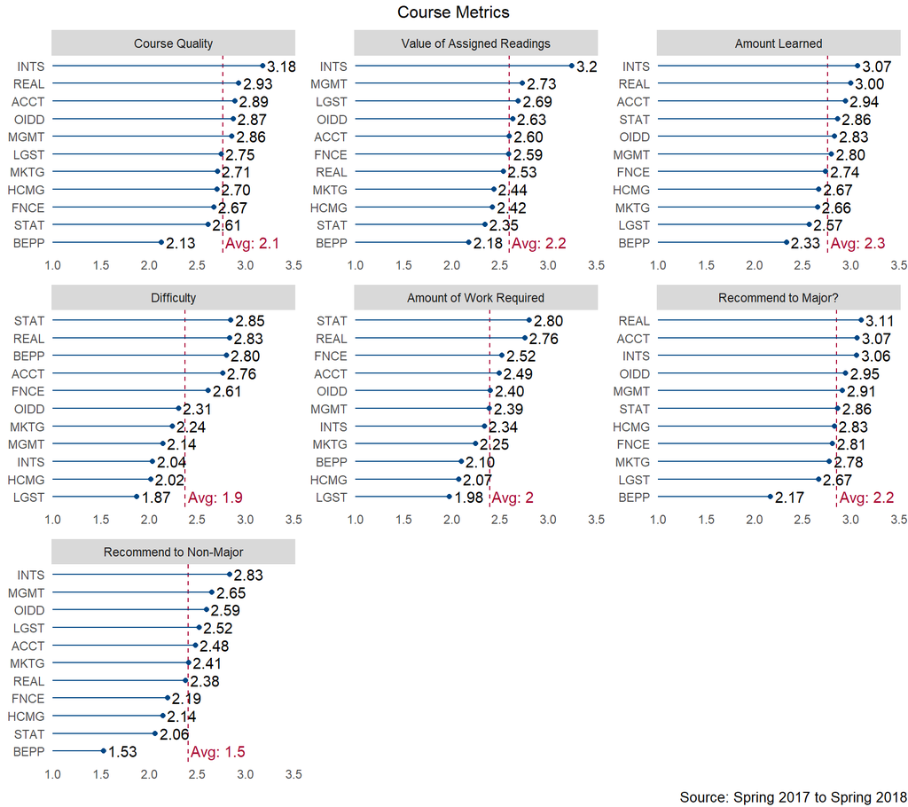

```r
dept_plots %>%
  filter(question_type == "Course") %>%
  pull(plot) %>%
  grid.arrange(grobs = ., top = "Course Metrics", bottom = textGrob("Source: Spring 2017 to Spring 2018",
                                                                    gp = gpar(fontsize=10),
                                                                    hjust=1, x=1))
```

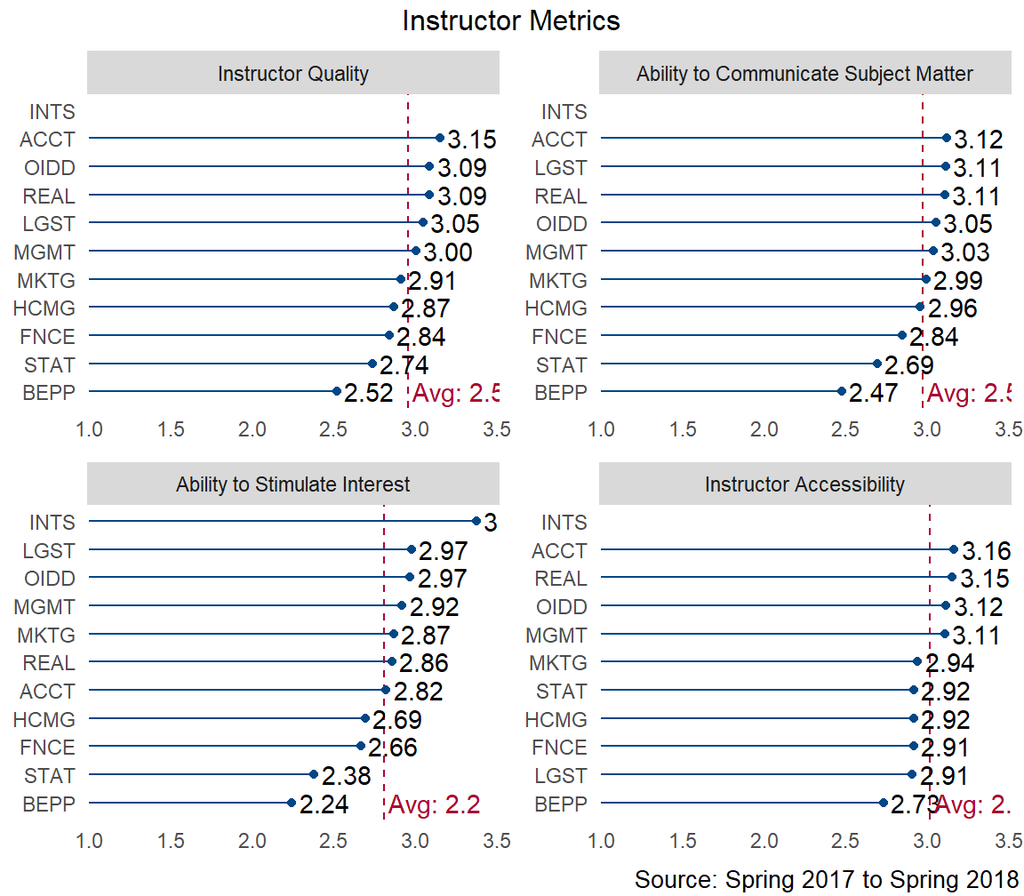

```r
dept_plots %>%
  filter(question_type == "Instructor") %>%
  pull(plot) %>%
  grid.arrange(grobs = ., top = "Instructor Metrics",
               bottom = textGrob("Source: Spring 2017 to Spring 2018",
                                 gp = gpar(fontsize=10),
                                 hjust=1.01, x=1))
```

## 4.2 Which course is the “best bang for your utility”?

```r
course_quality_to_price <-
  course_metrics %>%
  distinct(Course, `Course Quality`, Title, clearing_price) %>%
  mutate(title_length = length(Title)) %>%
  arrange(Course, title_length) %>%
  group_by(Course) %>%
  filter(row_number() == 1) %>%
  ungroup() %>%
  mutate(dept = str_sub(Course, 1, 4)) %>%
  rename(quality = `Course Quality`) %>%
  filter(complete.cases(.))

course_quality_to_price %>%
  hchart("scatter", hcaes(x = clearing_price, y = quality, group = dept, course = Course,
                          title = Title)) %>%
  hc_tooltip(pointFormat = "<span style=\"color:{series.color}\">{point.course}</span>:{point.title}<br/>
             Clearing Price: <b>{point.x:,.1f}</b><br/>
             Course Quality: <b>{point.y:,.2f}</b><br/>",
             shared = TRUE) %>%
  hc_xAxis(title = list(text = "Average Clearing Price")) %>%
  hc_yAxis(title = list(text = "Average Course Quality")) %>%
  hc_title(text = 'Which course is the "best bang for your utility"?') %>%
  hc_subtitle(text = "Value courses are in the top left corner") %>%
  hc_credits(enabled = TRUE, text = "Source: Spring 2016 to Spring 2017") %>%
  hc_add_theme(hc_theme_merge(
    getOption("highcharter.theme"),
    hc_theme(colors = wharton_col[c('wharton_blue','wharton_red','bay_blue','morning_yellow','college_grey',
                                    'evening_red','sunset_red','night_street','marine_grey','heritage_red')] %>% unname()))) %>%
  hc_size(height = 700)
```

[interactive chart not shown]

## 4.3 Top 10 and Bottom 10 Instructors for Fall 2018?

This list is restricted to those teaching in the fall.

```r
instructor_metrics %>%
  arrange(desc(`Instructor Quality`)) %>%
  mutate(
    rnk = row_number()
    , `Instructor Quality` = formatC(`Instructor Quality`, format = 'f', digits = 2)
  ) %>%
  head(10) %>%
  select(rnk, instructors, `Instructor Quality`) %>%
  left_join(
    instructor_metrics %>%
      arrange(`Instructor Quality`) %>%
      mutate(
        rnk = row_number()
        , `Instructor Quality` = formatC(`Instructor Quality`, format = 'f', digits = 2)
      ) %>%
      head(10) %>%
      select(rnk, instructors, `Instructor Quality`)
    , by = 'rnk'
  ) %>%
  htmlTable(
    rnames = FALSE
    , caption = "Top 10 and Bottom 10 Instructors for Fall 2017"
    , align = c("clclc")
    , col.rgroup = c("none", "#F7F7F7")
    , cgroup = c("", "Top 10", "Bottom 10")
    , n.cgroup = c(1,2,2)
    , header = c("Rank", rep(c("Instructor", "Quality"), 2))
    , css.cell = "padding-left: 2em; padding-right: 2em;"
  )
```

| Top 10 and Bottom 10 Instructors for Fall 2017 Rank | Top 10 and Bottom 10 Instructors for Fall 2017 | Top 10 and Bottom 10 Instructors for Fall 2017 Top 10 Instructor | Top 10 and Bottom 10 Instructors for Fall 2017 Top 10 Quality | Top 10 and Bottom 10 Instructors for Fall 2017 | Top 10 and Bottom 10 Instructors for Fall 2017 Bottom 10 Instructor | Top 10 and Bottom 10 Instructors for Fall 2017 Bottom 10 Quality |
| --- | --- | --- | --- | --- | --- | --- |
| 1 |  | Siggelkow, Nicolaj | 3.85 |  | Kirtley, Jacqueline | 0.79 |
| 2 |  | Hosanagar, Kartik | 3.64 |  | Eliashberg, Jehoshua | 1.77 |
| 3 |  | Bradlow, Eric | 3.64 |  | Raff, Daniel | 1.88 |
| 4 |  | Cachon, Gerard | 3.63 |  | Mitchell, Olivia | 1.93 |
| 5 |  | Massey, Cade | 3.60 |  | Shaman, Paul | 2.00 |
| 6 |  | Borghese, Robert J | 3.58 |  | Gomes, Joao | 2.04 |
| 7 |  | Emanuel, Ezekiel | 3.58 |  | Clemons, Eric K | 2.05 |
| 8 |  | Hernandez, Exequiel | 3.58 |  | Zaring, David | 2.11 |
| 9 |  | Wessels, David | 3.56 |  | Martin, William | 2.17 |
| 10 |  | Feldman, Emilie | 3.54 |  | Orts, Eric | 2.27 |